# Class 14

Erin Li

2023-11-14

This week we are looking at differential expression analysis.

The data for this hands-on session comes from a published RNA-seq experiment where airway smooth muscle cells were treated with dexamethasone, a synthetic glucocorticoid steroid with anti-inflammatory effects (Himes et al. 2014).

# Import/Read the data from Himes et al.

```r
counts <- read.csv("airway_scaledcounts.csv", row.names=1)
metadata <- read.csv("airway_metadata.csv")
```

```r
head(metadata)
```

```
##           id     dex celltype     geo_id
## 1 SRR1039508 control   N61311 GSM1275862
## 2 SRR1039509 treated   N61311 GSM1275863
## 3 SRR1039512 control  N052611 GSM1275866
## 4 SRR1039513 treated  N052611 GSM1275867
## 5 SRR1039516 control  N080611 GSM1275870
## 6 SRR1039517 treated  N080611 GSM1275871
```

Sanity check on corespondence of counts and metadata

```r
all(metadata$id==colnames(counts))
```

```
## [1] TRUE
```

Q2. How many ‘control’ cell lines do we have?

```r
n.control <- sum(metadata$dex == 'control')
n.control
```

```
## [1] 4
```

```r
control <- metadata[metadata[,"dex"]=="control",]
control.counts <- counts[ ,control$id]
control.mean <- rowSums( control.counts )/4
head(control.mean)
```

```
## ENSG00000000003 ENSG00000000005 ENSG00000000419 ENSG00000000457 ENSG00000000460
##          900.75            0.00          520.50          339.75           97.25
## ENSG00000000938
##            0.75
```

Q3. How would you make the above code in either approach more robust? Is there a function that could help here? Dynamic Count of Control Samples: Instead of hardcoding the divisor as 4 in rowSums(control.counts)/4, we can dynamically calculate the number of control samples. This ensures the code remains accurate even if the number of control samples changes.

Q4. Follow the same procedure for the treated samples (i.e. calculate the mean per gene across drug treated samples and assign to a labeled vector called treated.mean) ## Extract and summarize the treated (i.e. drug) samples

```r
treated <- metadata[metadata$dex == "treated",]
treated.counts <- counts[,treated$id]
treated.mean <- rowMeans(treated.counts)
```

Q5 (a). Create a scatter plot showing the mean of the treated samples against the mean of the control samples. Your plot should look something like the following.

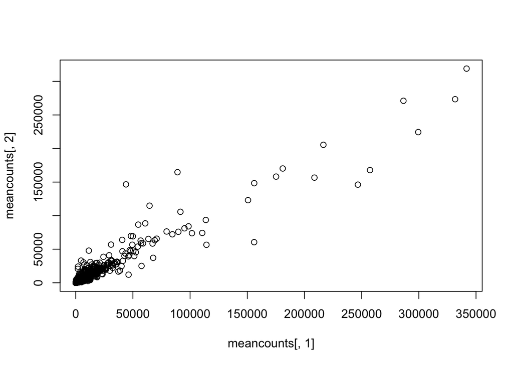

```r
meancounts <- data.frame(control.mean, treated.mean)
plot(meancounts[,1], meancounts[,2])
```

Q5 (b).You could also use the ggplot2 package to make this figure producing the plot below. What geom_?() function would you use for this plot? geom_point()

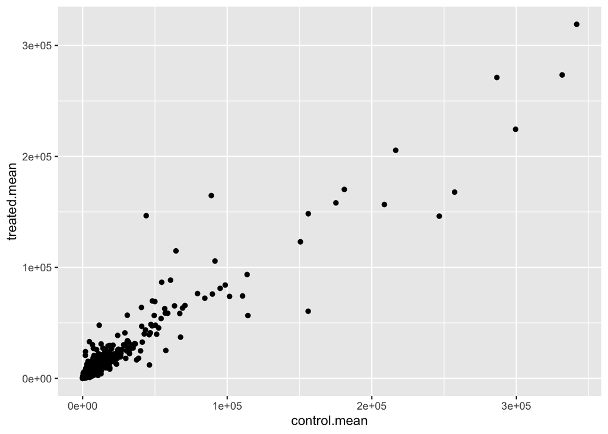

```r
library(ggplot2)

ggplot(meancounts) +
  aes(control.mean,treated.mean) +
  geom_point()
```

Q6. Try plotting both axes on a log scale. What is the argument to plot() that allows you to do this? log=‘xy’

We will make a log-log plot to draw out this skewed data and see what is going on

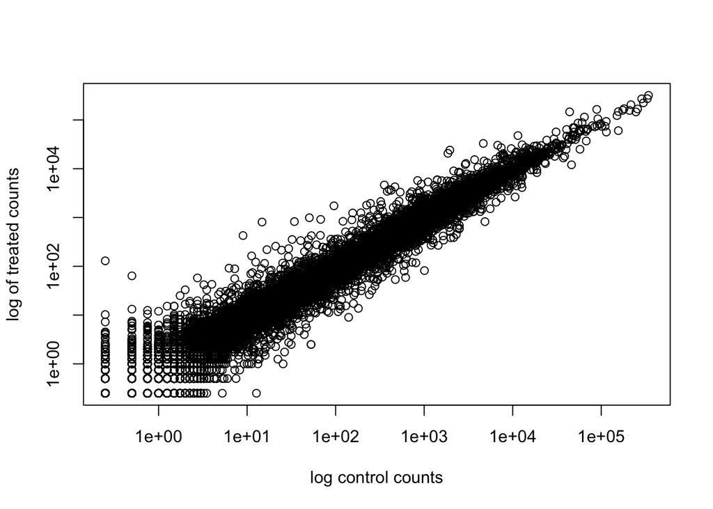

```r
plot(meancounts[,1], meancounts[,2],log='xy',
     xlab="log control counts",
     ylab="log of treated counts")
```

```r
meancounts$log2fc <- log2(meancounts$treated.mean/meancounts$control.mean)
```

```r
head(meancounts)
```

```
##                 control.mean treated.mean      log2fc
## ENSG00000000003       900.75       658.00 -0.45303916
## ENSG00000000005         0.00         0.00         NaN
## ENSG00000000419       520.50       546.00  0.06900279
## ENSG00000000457       339.75       316.50 -0.10226805
## ENSG00000000460        97.25        78.75 -0.30441833
## ENSG00000000938         0.75         0.00        -Inf
```

```r
zero.vals <- which(meancounts[,1:2]==0, arr.ind=TRUE)

to.rm <- unique(zero.vals[,1])
mycounts <- meancounts[-to.rm,]
head(mycounts)
```

```
##                 control.mean treated.mean      log2fc
## ENSG00000000003       900.75       658.00 -0.45303916
## ENSG00000000419       520.50       546.00  0.06900279
## ENSG00000000457       339.75       316.50 -0.10226805
## ENSG00000000460        97.25        78.75 -0.30441833
## ENSG00000000971      5219.00      6687.50  0.35769358
## ENSG00000001036      2327.00      1785.75 -0.38194109
```

Q7. What is the purpose of the arr.ind argument in the which() function call above? Why would we then take the first column of the output and need to call the unique() function? The which() function in R is used to identify the indices of elements that meet a certain condition in an array or matrix. arr.ind=TRUE is used to obtain both row and column indices of zeros in the first two columns of meancounts. The unique row indices where zeros occur are then extracted to identify which rows (likely corresponding to genes) should be removed from the dataset, as these rows contain zero counts in at least one of the samples and might not be informative for further analysis.

Q8. Using the up.ind vector above can you determine how many up regulated genes we have at the greater than 2 fc level? 250 Q9. Using the down.ind vector above can you determine how many down regulated genes we have at the greater than 2 fc level? 367 Q10. Do you trust these results? Why or why not? We will not fully trust, We have not done anything yet to determine whether the differences we are seeing are significant. These results in their current form are likely to be very misleading.

```r
up.ind <- mycounts$log2fc > 2
sum(up.ind)
```

```
## [1] 250
```

```r
down.ind <- mycounts$log2fc < (-2)
sum(down.ind)
```

```
## [1] 367
```

```r
library(DESeq2)
citation("DESeq2")
```

```
##
##   Love, M.I., Huber, W., Anders, S. Moderated estimation of fold change
##   and dispersion for RNA-seq data with DESeq2 Genome Biology 15(12):550
##   (2014)
##
## A BibTeX entry for LaTeX users is
##
##   @Article{,
##     title = {Moderated estimation of fold change and dispersion for RNA-seq data with DESeq2},
##     author = {Michael I. Love and Wolfgang Huber and Simon Anders},
##     year = {2014},
##     journal = {Genome Biology},
##     doi = {10.1186/s13059-014-0550-8},
##     volume = {15},
##     issue = {12},
##     pages = {550},
##   }
```

```r
dds <- DESeqDataSetFromMatrix(countData=counts,
                              colData=metadata,
                              design=~dex)
dds
```

```
## class: DESeqDataSet
## dim: 38694 8
## metadata(1): version
## assays(1): counts
## rownames(38694): ENSG00000000003 ENSG00000000005 ... ENSG00000283120
##   ENSG00000283123
## rowData names(0):
## colnames(8): SRR1039508 SRR1039509 ... SRR1039520 SRR1039521
## colData names(4): id dex celltype geo_id
```

```
## using ntop=500 top features by variance
```

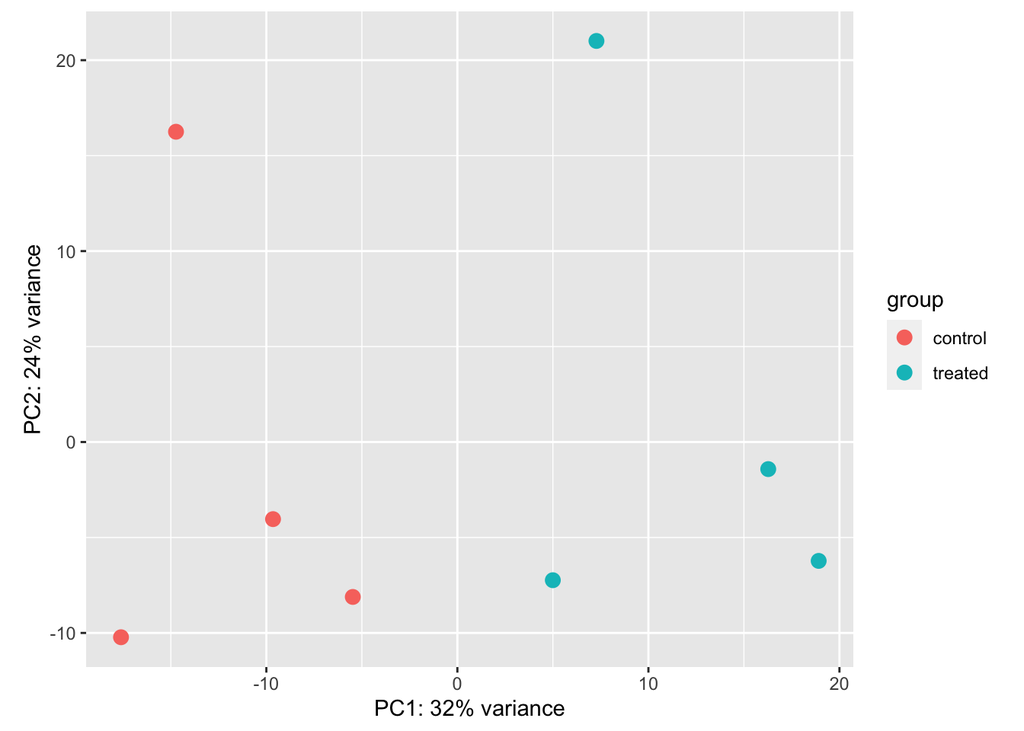

```r
vsd <- vst(dds, blind = FALSE)
plotPCA(vsd, intgroup = c("dex"))
```

```r
pcaData <- plotPCA(vsd, intgroup=c("dex"), returnData=TRUE)
```

```
## using ntop=500 top features by variance
```

```r
head(pcaData)
```

```
##                   PC1        PC2   group     dex       name
## SRR1039508 -17.607922 -10.225252 control control SRR1039508
## SRR1039509   4.996738  -7.238117 treated treated SRR1039509
## SRR1039512  -5.474456  -8.113993 control control SRR1039512
## SRR1039513  18.912974  -6.226041 treated treated SRR1039513
## SRR1039516 -14.729173  16.252000 control control SRR1039516
## SRR1039517   7.279863  21.008034 treated treated SRR1039517
```

```r
# Calculate percent variance per PC for the plot axis labels
percentVar <- round(100 * attr(pcaData, "percentVar"))
```

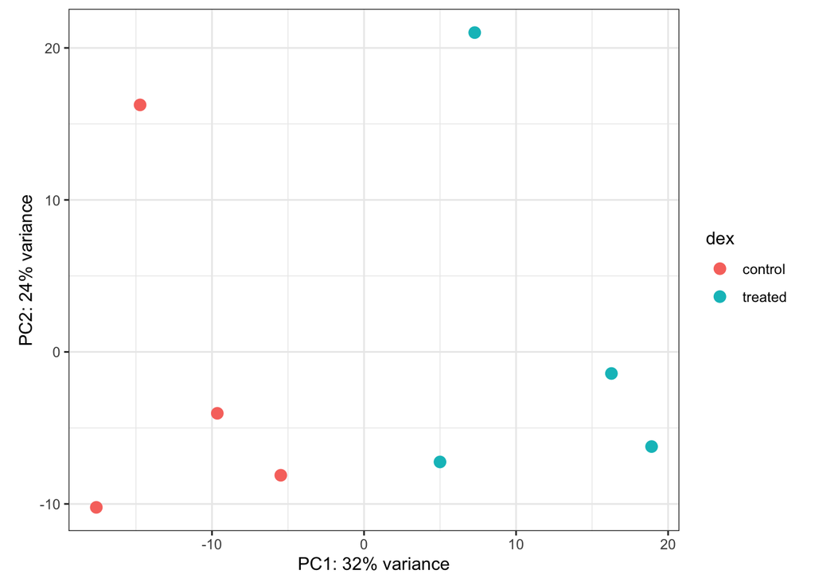

```r
ggplot(pcaData) +
  aes(x = PC1, y = PC2, color = dex) +
  geom_point(size =3) +
  xlab(paste0("PC1: ", percentVar[1], "% variance")) +
  ylab(paste0("PC2: ", percentVar[2], "% variance")) +
  coord_fixed() +
  theme_bw()
```

```r
dds <- DESeq(dds)
res <- results(dds)
res
```

```
## log2 fold change (MLE): dex treated vs control
## Wald test p-value: dex treated vs control
## DataFrame with 38694 rows and 6 columns
##                  baseMean log2FoldChange     lfcSE      stat    pvalue
##                 <numeric>      <numeric> <numeric> <numeric> <numeric>
## ENSG00000000003  747.1942     -0.3507030  0.168246 -2.084470 0.0371175
## ENSG00000000005    0.0000             NA        NA        NA        NA
## ENSG00000000419  520.1342      0.2061078  0.101059  2.039475 0.0414026
## ENSG00000000457  322.6648      0.0245269  0.145145  0.168982 0.8658106
## ENSG00000000460   87.6826     -0.1471420  0.257007 -0.572521 0.5669691
## ...                   ...            ...       ...       ...       ...
## ENSG00000283115  0.000000             NA        NA        NA        NA
## ENSG00000283116  0.000000             NA        NA        NA        NA
## ENSG00000283119  0.000000             NA        NA        NA        NA
## ENSG00000283120  0.974916      -0.668258   1.69456 -0.394354  0.693319
## ENSG00000283123  0.000000             NA        NA        NA        NA
##                      padj
##                 <numeric>
## ENSG00000000003  0.163035
## ENSG00000000005        NA
## ENSG00000000419  0.176032
## ENSG00000000457  0.961694
## ENSG00000000460  0.815849
## ...                   ...
## ENSG00000283115        NA
## ENSG00000283116        NA
## ENSG00000283119        NA
## ENSG00000283120        NA
## ENSG00000283123        NA
```

```r
summary(res)
```

```
##
## out of 25258 with nonzero total read count
## adjusted p-value < 0.1
## LFC > 0 (up)       : 1563, 6.2%
## LFC < 0 (down)     : 1188, 4.7%
## outliers [1]       : 142, 0.56%
## low counts [2]     : 9971, 39%
## (mean count < 10)
## [1] see 'cooksCutoff' argument of ?results
## [2] see 'independentFiltering' argument of ?results
```

```r
res05 <- results(dds, alpha=0.05)
summary(res05)
```

```
##
## out of 25258 with nonzero total read count
## adjusted p-value < 0.05
## LFC > 0 (up)       : 1236, 4.9%
## LFC < 0 (down)     : 933, 3.7%
## outliers [1]       : 142, 0.56%
## low counts [2]     : 9033, 36%
## (mean count < 6)
## [1] see 'cooksCutoff' argument of ?results
## [2] see 'independentFiltering' argument of ?results
```

```r
library("AnnotationDbi")
library("org.Hs.eg.db")
columns(org.Hs.eg.db)
```

```
##  [1] "ACCNUM"       "ALIAS"        "ENSEMBL"      "ENSEMBLPROT"  "ENSEMBLTRANS"
##  [6] "ENTREZID"     "ENZYME"       "EVIDENCE"     "EVIDENCEALL"  "GENENAME"
## [11] "GENETYPE"     "GO"           "GOALL"        "IPI"          "MAP"
## [16] "OMIM"         "ONTOLOGY"     "ONTOLOGYALL"  "PATH"         "PFAM"
## [21] "PMID"         "PROSITE"      "REFSEQ"       "SYMBOL"       "UCSCKG"
## [26] "UNIPROT"
```

```r
res$symbol <- mapIds(org.Hs.eg.db,
                     keys=row.names(res), # Our genenames
                     keytype="ENSEMBL",        # The format of our genenames
                     column="SYMBOL",          # The new format we want to add
                     multiVals="first")
head(res)
```

```
## log2 fold change (MLE): dex treated vs control
## Wald test p-value: dex treated vs control
## DataFrame with 6 rows and 7 columns
##                   baseMean log2FoldChange     lfcSE      stat    pvalue
##                  <numeric>      <numeric> <numeric> <numeric> <numeric>
## ENSG00000000003 747.194195     -0.3507030  0.168246 -2.084470 0.0371175
## ENSG00000000005   0.000000             NA        NA        NA        NA
## ENSG00000000419 520.134160      0.2061078  0.101059  2.039475 0.0414026
## ENSG00000000457 322.664844      0.0245269  0.145145  0.168982 0.8658106
## ENSG00000000460  87.682625     -0.1471420  0.257007 -0.572521 0.5669691
## ENSG00000000938   0.319167     -1.7322890  3.493601 -0.495846 0.6200029
##                      padj      symbol
##                 <numeric> <character>
## ENSG00000000003  0.163035      TSPAN6
## ENSG00000000005        NA        TNMD
## ENSG00000000419  0.176032        DPM1
## ENSG00000000457  0.961694       SCYL3
## ENSG00000000460  0.815849       FIRRM
## ENSG00000000938        NA         FGR
```

Q11. Run the mapIds() function two more times to add the Entrez ID and UniProt accession and GENENAME as new columns called res$entrez, res$uniprot and res$genename.

```r
res$entrez <- mapIds(org.Hs.eg.db,
                     keys=row.names(res),
                     column="ENTREZID",
                     keytype="ENSEMBL",
                     multiVals="first")
res$uniprot <- mapIds(org.Hs.eg.db,
                     keys=row.names(res),
                     column="UNIPROT",
                     keytype="ENSEMBL",
                     multiVals="first")
res$genename <- mapIds(org.Hs.eg.db,
                     keys=row.names(res),
                     column="GENENAME",
                     keytype="ENSEMBL",
                     multiVals="first")
head(res)
```

```
## log2 fold change (MLE): dex treated vs control
## Wald test p-value: dex treated vs control
## DataFrame with 6 rows and 10 columns
##                   baseMean log2FoldChange     lfcSE      stat    pvalue
##                  <numeric>      <numeric> <numeric> <numeric> <numeric>
## ENSG00000000003 747.194195     -0.3507030  0.168246 -2.084470 0.0371175
## ENSG00000000005   0.000000             NA        NA        NA        NA
## ENSG00000000419 520.134160      0.2061078  0.101059  2.039475 0.0414026
## ENSG00000000457 322.664844      0.0245269  0.145145  0.168982 0.8658106
## ENSG00000000460  87.682625     -0.1471420  0.257007 -0.572521 0.5669691
## ENSG00000000938   0.319167     -1.7322890  3.493601 -0.495846 0.6200029
##                      padj      symbol      entrez     uniprot
##                 <numeric> <character> <character> <character>
## ENSG00000000003  0.163035      TSPAN6        7105  A0A024RCI0
## ENSG00000000005        NA        TNMD       64102      Q9H2S6
## ENSG00000000419  0.176032        DPM1        8813      O60762
## ENSG00000000457  0.961694       SCYL3       57147      Q8IZE3
## ENSG00000000460  0.815849       FIRRM       55732  A0A024R922
## ENSG00000000938        NA         FGR        2268      P09769
##                               genename
##                            <character>
## ENSG00000000003          tetraspanin 6
## ENSG00000000005            tenomodulin
## ENSG00000000419 dolichyl-phosphate m..
## ENSG00000000457 SCY1 like pseudokina..
## ENSG00000000460 FIGNL1 interacting r..
## ENSG00000000938 FGR proto-oncogene, ..
```

```r
ord <- order( res$padj )
#View(res[ord,])
head(res[ord,])
```

```
## log2 fold change (MLE): dex treated vs control
## Wald test p-value: dex treated vs control
## DataFrame with 6 rows and 10 columns
##                  baseMean log2FoldChange     lfcSE      stat      pvalue
##                 <numeric>      <numeric> <numeric> <numeric>   <numeric>
## ENSG00000152583   954.771        4.36836 0.2371268   18.4220 8.74490e-76
## ENSG00000179094   743.253        2.86389 0.1755693   16.3120 8.10784e-60
## ENSG00000116584  2277.913       -1.03470 0.0650984  -15.8944 6.92855e-57
## ENSG00000189221  2383.754        3.34154 0.2124058   15.7319 9.14433e-56
## ENSG00000120129  3440.704        2.96521 0.2036951   14.5571 5.26424e-48
## ENSG00000148175 13493.920        1.42717 0.1003890   14.2164 7.25128e-46
##                        padj      symbol      entrez     uniprot
##                   <numeric> <character> <character> <character>
## ENSG00000152583 1.32441e-71     SPARCL1        8404  A0A024RDE1
## ENSG00000179094 6.13966e-56        PER1        5187      O15534
## ENSG00000116584 3.49776e-53     ARHGEF2        9181      Q92974
## ENSG00000189221 3.46227e-52        MAOA        4128      P21397
## ENSG00000120129 1.59454e-44       DUSP1        1843      B4DU40
## ENSG00000148175 1.83034e-42        STOM        2040      F8VSL7
##                               genename
##                            <character>
## ENSG00000152583           SPARC like 1
## ENSG00000179094 period circadian reg..
## ENSG00000116584 Rho/Rac guanine nucl..
## ENSG00000189221    monoamine oxidase A
## ENSG00000120129 dual specificity pho..
## ENSG00000148175               stomatin
```

```r
write.csv(res[ord,], "deseq_results.csv")
```

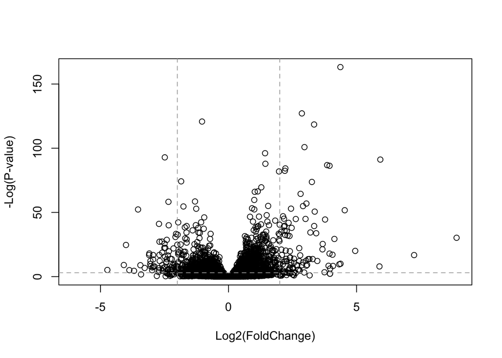

```r
plot( res$log2FoldChange,  -log(res$padj),
 ylab="-Log(P-value)", xlab="Log2(FoldChange)")

# Add some cut-off lines
abline(v=c(-2,2), col="darkgray", lty=2)
abline(h=-log(0.05), col="darkgray", lty=2)
```

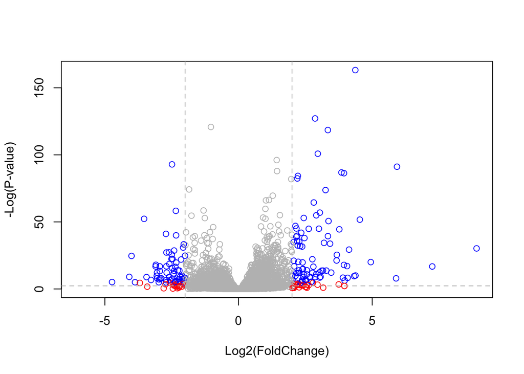

```r
# Setup our custom point color vector
mycols <- rep("gray", nrow(res))
mycols[ abs(res$log2FoldChange) > 2 ]  <- "red"

inds <- (res$padj < 0.01) & (abs(res$log2FoldChange) > 2 )
mycols[ inds ] <- "blue"

# Volcano plot with custom colors
plot( res$log2FoldChange,  -log(res$padj),
 col=mycols, ylab="-Log(P-value)", xlab="Log2(FoldChange)" )

# Cut-off lines
abline(v=c(-2,2), col="gray", lty=2)
abline(h=-log(0.1), col="gray", lty=2)
```

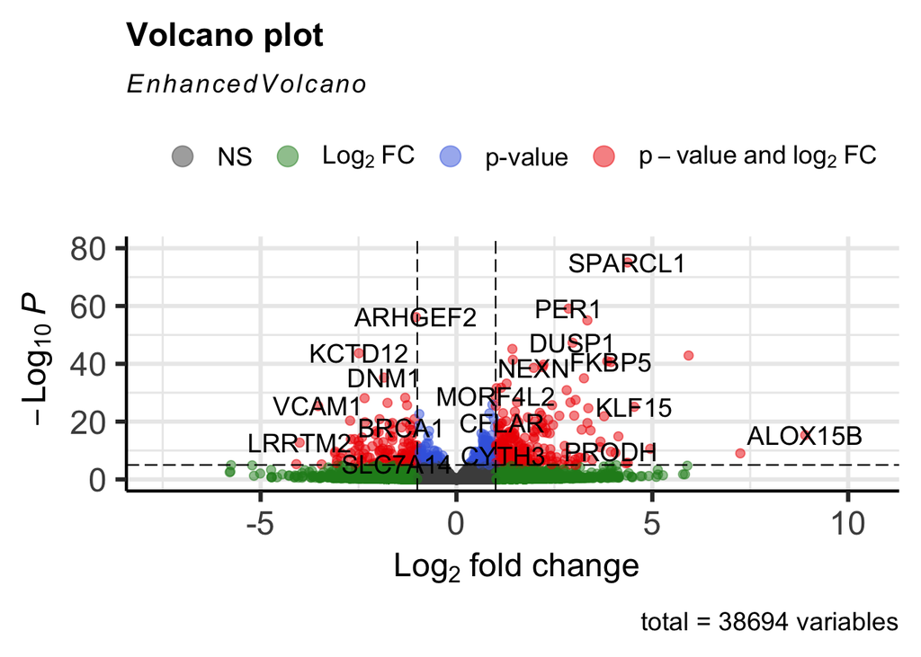

```r
library(EnhancedVolcano)
x <- as.data.frame(res)

EnhancedVolcano(x,
    lab = x$symbol,
    x = 'log2FoldChange',
    y = 'pvalue')
```

```r
library(gage)
library(gageData)
library(pathview)
data(kegg.sets.hs)
data(sigmet.idx.hs)

# Focus on signaling and metabolic pathways only
kegg.sets.hs = kegg.sets.hs[sigmet.idx.hs]

# Examine the first 3 pathways
head(kegg.sets.hs, 3)
```

```
## $`hsa00232 Caffeine metabolism`
## [1] "10"   "1544" "1548" "1549" "1553" "7498" "9"
##
## $`hsa00983 Drug metabolism - other enzymes`
##  [1] "10"     "1066"   "10720"  "10941"  "151531" "1548"   "1549"   "1551"
##  [9] "1553"   "1576"   "1577"   "1806"   "1807"   "1890"   "221223" "2990"
## [17] "3251"   "3614"   "3615"   "3704"   "51733"  "54490"  "54575"  "54576"
## [25] "54577"  "54578"  "54579"  "54600"  "54657"  "54658"  "54659"  "54963"
## [33] "574537" "64816"  "7083"   "7084"   "7172"   "7363"   "7364"   "7365"
## [41] "7366"   "7367"   "7371"   "7372"   "7378"   "7498"   "79799"  "83549"
## [49] "8824"   "8833"   "9"      "978"
##
## $`hsa00230 Purine metabolism`
##   [1] "100"    "10201"  "10606"  "10621"  "10622"  "10623"  "107"    "10714"
##   [9] "108"    "10846"  "109"    "111"    "11128"  "11164"  "112"    "113"
```

[output cut: 19 more lines]

```r
foldchanges = res$log2FoldChange
names(foldchanges) = res$entrez
head(foldchanges)
```

```
##        7105       64102        8813       57147       55732        2268
## -0.35070302          NA  0.20610777  0.02452695 -0.14714205 -1.73228897
```

```r
# Get the results
keggres = gage(foldchanges, gsets=kegg.sets.hs)
```

```r
attributes(keggres)
```

```
## $names
## [1] "greater" "less"    "stats"
```

```r
# Look at the first few down (less) pathways
head(keggres$less)
```

```
##                                                         p.geomean stat.mean
## hsa04672 Intestinal immune network for IgA production 0.006043452 -2.560547
## hsa04340 Hedgehog signaling pathway                   0.013323955 -2.248547
## hsa04916 Melanogenesis                                0.030996739 -1.877209
## hsa04972 Pancreatic secretion                         0.037135109 -1.794718
## hsa04612 Antigen processing and presentation          0.044082096 -1.716738
## hsa04640 Hematopoietic cell lineage                   0.071446108 -1.471776
##                                                             p.val     q.val
## hsa04672 Intestinal immune network for IgA production 0.006043452 0.9763115
## hsa04340 Hedgehog signaling pathway                   0.013323955 0.9763115
## hsa04916 Melanogenesis                                0.030996739 0.9763115
## hsa04972 Pancreatic secretion                         0.037135109 0.9763115
## hsa04612 Antigen processing and presentation          0.044082096 0.9763115
## hsa04640 Hematopoietic cell lineage                   0.071446108 0.9763115
##                                                       set.size        exp1
## hsa04672 Intestinal immune network for IgA production       47 0.006043452
## hsa04340 Hedgehog signaling pathway                         56 0.013323955
## hsa04916 Melanogenesis                                     101 0.030996739
## hsa04972 Pancreatic secretion                              101 0.037135109
## hsa04612 Antigen processing and presentation                75 0.044082096
## hsa04640 Hematopoietic cell lineage                         88 0.071446108
```

```r
pathview(gene.data=foldchanges, pathway.id="hsa04110")
```

```
## Info: Working in directory /Users/wenxili/Desktop/UCSD/BIMM 143/Class 13
```

```
## Info: Writing image file hsa04110.pathview.png
```

```r
# A different PDF based output of the same data
pathview(gene.data=foldchanges, pathway.id="hsa04110", kegg.native=FALSE)
```

```
##      [,1] [,2]
## [1,] "9"  "300"
## [2,] "9"  "306"
```

```
## Info: Working in directory /Users/wenxili/Desktop/UCSD/BIMM 143/Class 13
```

```
## Info: Writing image file hsa04110.pathview.pdf
```

```r
## Focus on top 5 upregulated pathways here for demo purposes only
keggrespathways <- rownames(keggres$greater)[1:5]

# Extract the 8 character long IDs part of each string
keggresids = substr(keggrespathways, start=1, stop=8)
keggresids
```

```
## [1] "hsa00500" "hsa00330" "hsa04910" "hsa04510" "hsa04920"
```

```r
pathview(gene.data=foldchanges, pathway.id=keggresids, species="hsa")
```

```
## Info: Working in directory /Users/wenxili/Desktop/UCSD/BIMM 143/Class 13
```

```
## Info: Writing image file hsa00500.pathview.png
```

```
## Info: some node width is different from others, and hence adjusted!
```

```
## Info: Working in directory /Users/wenxili/Desktop/UCSD/BIMM 143/Class 13
```

```
## Info: Writing image file hsa00330.pathview.png
```

```
## Info: Working in directory /Users/wenxili/Desktop/UCSD/BIMM 143/Class 13
```

```
## Info: Writing image file hsa04910.pathview.png
```

```
## Info: Working in directory /Users/wenxili/Desktop/UCSD/BIMM 143/Class 13
```

```
## Info: Writing image file hsa04510.pathview.png
```

```
## Info: Working in directory /Users/wenxili/Desktop/UCSD/BIMM 143/Class 13
```

```
## Info: Writing image file hsa04920.pathview.png
```

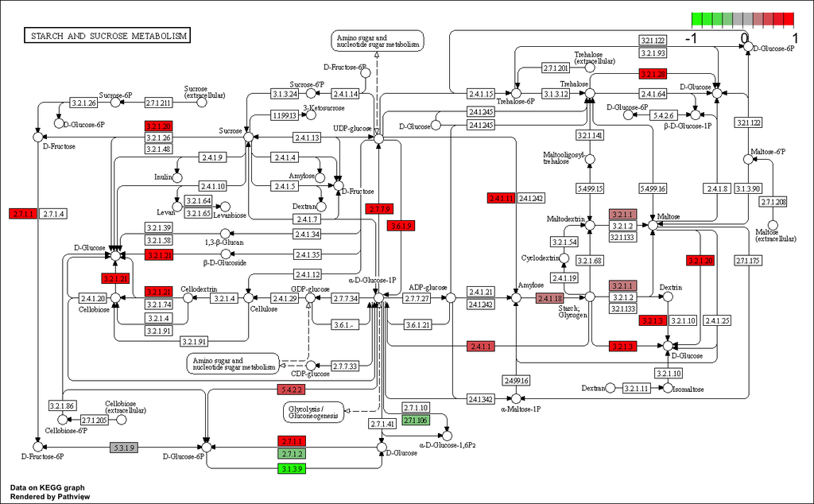

hsa00500

Q. Can you do the same procedure as above to plot the pathview figures for the top 5 down-reguled pathways?

```r
## Focus on top 5 downregulated pathways
keggrespathways_down <- rownames(keggres$less)[1:5]

# Extract the 8 character long IDs part of each string
keggresids_down = substr(keggrespathways_down, start=1, stop=8)
keggresids_down
```

```
## [1] "hsa04672" "hsa04340" "hsa04916" "hsa04972" "hsa04612"
```

```
## Info: Working in directory /Users/wenxili/Desktop/UCSD/BIMM 143/Class 13
```

```
## Info: Writing image file hsa04672.pathview.png
```

```
## Info: Working in directory /Users/wenxili/Desktop/UCSD/BIMM 143/Class 13
```

```
## Info: Writing image file hsa04340.pathview.png
```

```
## Info: Working in directory /Users/wenxili/Desktop/UCSD/BIMM 143/Class 13
```

```
## Info: Writing image file hsa04916.pathview.png
```

```
## Info: Working in directory /Users/wenxili/Desktop/UCSD/BIMM 143/Class 13
```

```
## Info: Writing image file hsa04972.pathview.png
```

```
## Info: Working in directory /Users/wenxili/Desktop/UCSD/BIMM 143/Class 13
```

```
## Info: Writing image file hsa04612.pathview.png
```

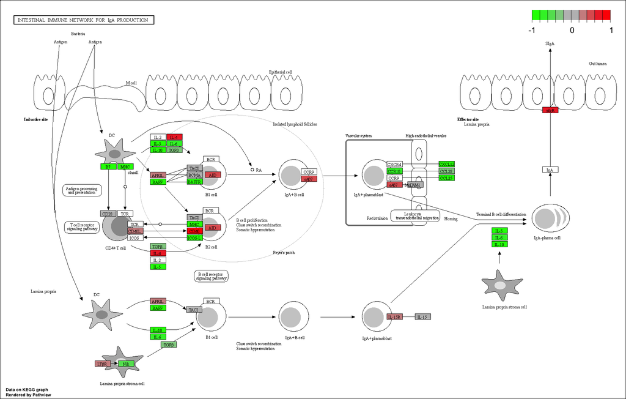

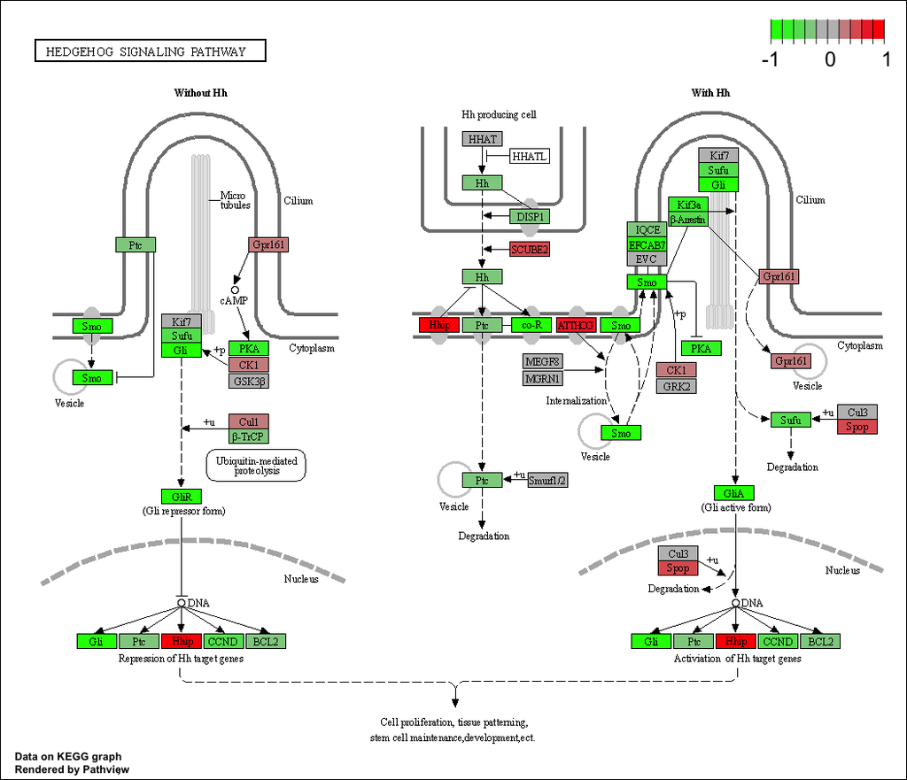

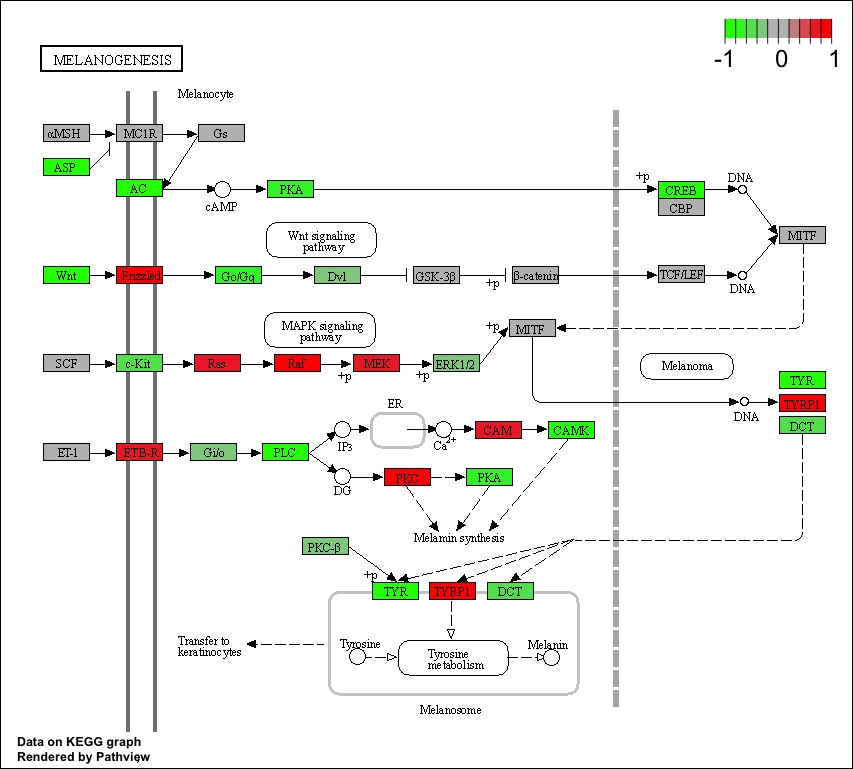

[figure not shown]

hsa04972

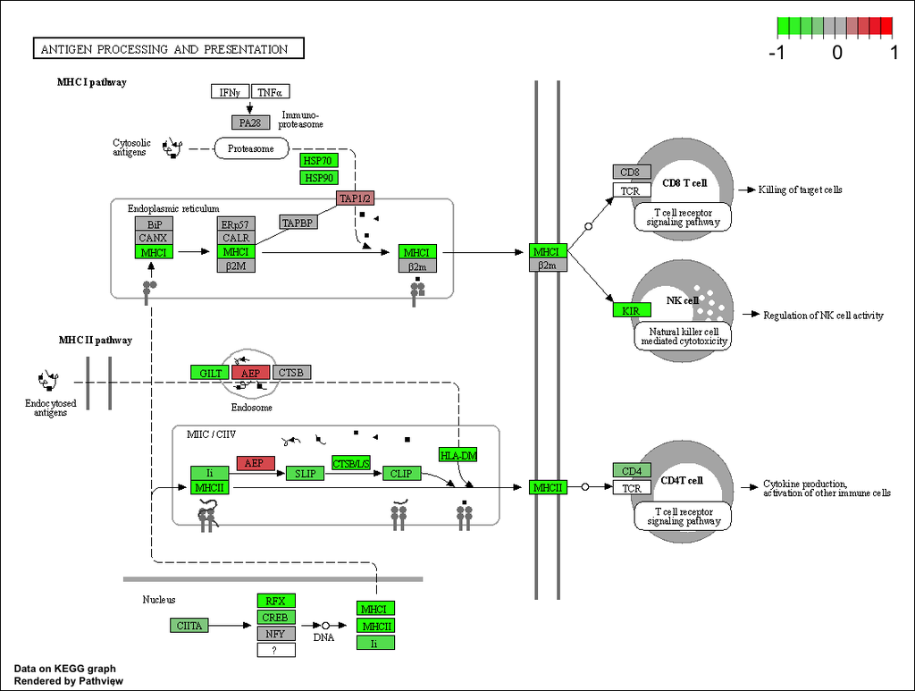

hsa04612

```r
# Plot Pathview for each downregulated pathway
for(pathway_id in keggresids_down) {
    pathview(gene.data = foldchanges, pathway.id = pathway_id, species = "hsa")
}
```

```r
data(go.sets.hs)
data(go.subs.hs)

# Focus on Biological Process subset of GO
gobpsets = go.sets.hs[go.subs.hs$BP]

gobpres = gage(foldchanges, gsets=gobpsets, same.dir=TRUE)

lapply(gobpres, head)
```

```
## $greater
##                                                                               p.geomean
## GO:0071294 cellular response to zinc ion                                   8.906565e-05
## GO:0006006 glucose metabolic process                                       5.933995e-04
## GO:0071241 cellular response to inorganic substance                        1.143075e-03
## GO:0048387 negative regulation of retinoic acid receptor signaling pathway 1.172337e-03
## GO:0019318 hexose metabolic process                                        1.263428e-03
## GO:0005996 monosaccharide metabolic process                                1.413832e-03
##                                                                            stat.mean
## GO:0071294 cellular response to zinc ion                                    4.607838
## GO:0006006 glucose metabolic process                                        3.265975
## GO:0071241 cellular response to inorganic substance                         3.101917
## GO:0048387 negative regulation of retinoic acid receptor signaling pathway  3.242198
## GO:0019318 hexose metabolic process                                         3.036983
## GO:0005996 monosaccharide metabolic process                                 3.000297
##                                                                                   p.val
## GO:0071294 cellular response to zinc ion                                   8.906565e-05
## GO:0006006 glucose metabolic process                                       5.933995e-04
## GO:0071241 cellular response to inorganic substance                        1.143075e-03
## GO:0048387 negative regulation of retinoic acid receptor signaling pathway 1.172337e-03
## GO:0019318 hexose metabolic process                                        1.263428e-03
## GO:0005996 monosaccharide metabolic process                                1.413832e-03
##                                                                                q.val
## GO:0071294 cellular response to zinc ion                                   0.3893950
## GO:0006006 glucose metabolic process                                       0.9029119
## GO:0071241 cellular response to inorganic substance                        0.9029119
## GO:0048387 negative regulation of retinoic acid receptor signaling pathway 0.9029119
## GO:0019318 hexose metabolic process                                        0.9029119
## GO:0005996 monosaccharide metabolic process                                0.9029119
##                                                                            set.size
## GO:0071294 cellular response to zinc ion                                         11
## GO:0006006 glucose metabolic process                                            211
## GO:0071241 cellular response to inorganic substance                              83
## GO:0048387 negative regulation of retinoic acid receptor signaling pathway       27
## GO:0019318 hexose metabolic process                                             247
## GO:0005996 monosaccharide metabolic process                                     274
##                                                                                    exp1
## GO:0071294 cellular response to zinc ion                                   8.906565e-05
## GO:0006006 glucose metabolic process                                       5.933995e-04
## GO:0071241 cellular response to inorganic substance                        1.143075e-03
```

[output cut: 27 more lines]

```
## $stats
##                                                                            stat.mean
## GO:0071294 cellular response to zinc ion                                    4.607838
## GO:0006006 glucose metabolic process                                        3.265975
## GO:0071241 cellular response to inorganic substance                         3.101917
## GO:0048387 negative regulation of retinoic acid receptor signaling pathway  3.242198
## GO:0019318 hexose metabolic process                                         3.036983
## GO:0005996 monosaccharide metabolic process                                 3.000297
##                                                                                exp1
## GO:0071294 cellular response to zinc ion                                   4.607838
## GO:0006006 glucose metabolic process                                       3.265975
## GO:0071241 cellular response to inorganic substance                        3.101917
## GO:0048387 negative regulation of retinoic acid receptor signaling pathway 3.242198
## GO:0019318 hexose metabolic process                                        3.036983
## GO:0005996 monosaccharide metabolic process                                3.000297
```

```r
sig_genes <- res[res$padj <= 0.05 & !is.na(res$padj), "symbol"]
print(paste("Total number of significant genes:", length(sig_genes)))
```

```
## [1] "Total number of significant genes: 2181"
```

```r
write.table(sig_genes, file="significant_genes.txt", row.names=FALSE, col.names=FALSE, quote=FALSE)
```